# 4 HPC introduction

If you work at IBED you can get access to the Crunchomics HPC, the Genomics Compute Environment for SILS and IBED. If you need access to Crunchomics, send an email to Wim de Leeuw w.c.deleeuw@uva.nl to get an account set up by giving him your UvA netID.

Using an HPC works a bit differently than running jobs on your computer, below you find a simplified schematic:

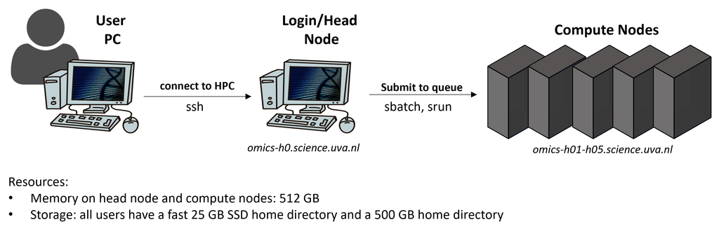

Very briefly, you can from your laptop log into an HPC where you then have get access to the login node, sometimes also called head node. The purpose of a **login node** is to prepare to run a program (e.g., moving and editing files as well as compiling and preparing a job script). You then submit a job script from the head to the compute nodes via a job manager called SLURM. The **compute nodes** are used to actually run a program and **SLURM** is used to provide the users access to the resources (CPUs, memory) on the compute nodes for a certain amount of time.

**Important**

**Crunchomics etiquette**

You share the HPC with other people, therefore, take care to only ask for the resources you actually use. Some general rules:

On Crunchomics you:

- Are granted a storage of 500 GB. After the duration of your grant, or when your UvAnetID expires, your data will be removed from the HPC. If you need more storage space, contact the Crunchomics team.
- In your home directory, `/home/$USER` , you have 25 G of storage
- In your personal directory, `/zfs/omics/personal/$USER` , you can store up to 500 GB data
- For larger, collaborative projects you can contact the Crunchomics team and ask for a shared folder to which several team members can have access
- You are in charge of backing up your own data and Crunchomics is NOT an archiving system. To learn about data archiving options at UvA visit the [website of the computational support team](https://ibed.uva.nl/facilities/computational-facilities/ibed-computational-support-team/ibed-computational-support-team.html)
- A manual with more information and documentation about the cluster can be found [here](https://crunchomics-documentation.readthedocs.io/en/latest)

Crunchomics gives you access to:

- 5 compute nodes
- Each compute node has 512 GB of memory and 64 CPUs
- Access to two directories:
  - The home directory with 25 GB of storage
  - your personal directory, with 500 GB of storage

Some information about snapshots:

- Snapshots are made daily at 00.00.00 and kept for 2 weeks. This means that if you accidentally remove a file it can be restored up to 2 weeks after removal. This also means that even if you remove files to make space, these files will still count towards your quota for two weeks
- Data on Crunchomics is stored on multiple disks. Therefore, there is protection against disk failure. However, the data is not replicated and you are responsible for backing up and/or archiving your data.